# ReCell Case study v0.1 - Final-Final 082021

### TEST FOR LINEARITY AND INDEPENDENCE

**We will take the below approach to test this assumption**

- Make a plot of fitted values vs residuals.
- If they don't follow any pattern, then we say the model is linear and residuals are independent.
- Otherwise, the model is showing signs of non-linearity and residuals are not independent.

```python
# let us create a dataframe with actual, fitted and residual values
df_pred = pd.DataFrame()

df_pred["Actual Values"] = y_train  # actual values
df_pred[
    "Fitted Values"
] = (
    olsmod1.fittedvalues
)  # predicted values taking exp as we had log transform while fitting
df_pred["Residuals"] = olsmod1.resid  # residuals

df_pred
```

|  | Actual Values | Fitted Values | Residuals |
| --- | --- | --- | --- |
| 844 | 100.480 | 99.389 | 1.091 |
| 1539 | 111.680 | 117.018 | -5.338 |
| 3452 | 113.890 | 111.640 | 2.250 |
| 1727 | 64.090 | 70.524 | -6.434 |
| 1926 | 67.950 | 68.061 | -0.111 |
| ... | ... | ... | ... |
| 1130 | 68.170 | 68.561 | -0.391 |
| 1294 | 69.230 | 81.971 | -12.741 |
| 860 | 44.930 | 36.407 | 8.523 |
| 3507 | 247.192 | 249.947 | -2.755 |
| 3174 | 51.890 | 46.501 | 5.389 |

2499 rows × 3 columns

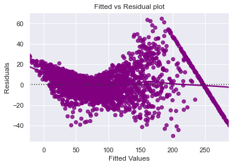

```python
# let's plot the fitted values vs residuals

sns.residplot(
    data=df_pred, x="Fitted Values", y="Residuals", color="purple", lowess=True
)
plt.xlabel("Fitted Values")
plt.ylabel("Residuals")
plt.title("Fitted vs Residual plot")
plt.show()
```

### TEST FOR NORMALITY

**We will follow the below approach**

- The shape of the histogram of residuals can give an initial idea about the normality.
- It can also be checked via a Q-Q plot of residuals. If the residuals follow a normal distribution, they will make a straight line plot, otherwise not.
- Other tests to check for normality includes the Shapiro-Wilk test.
  - Null hypothesis: Residuals are normally distributed
  - Alternate hypothesis: Residuals are not normally distributed

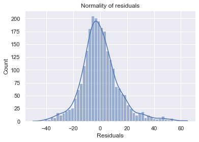

```python
sns.histplot(data=df_pred, x="Residuals", kde=True)
plt.title("Normality of residuals")
plt.show()
```

- The histogram of residuals does have a bell shape.

**Let's check the Q-Q plot.**

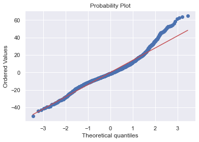

```python
import pylab
import scipy.stats as stats

stats.probplot(df_pred["Residuals"], dist="norm", plot=pylab)
plt.show()
```

- The residuals more or less follow a straight line except for the tails.

**Let's check the results of the Shapiro-Wilk test.**

```python
stats.shapiro(df_pred["Residuals"])
```

```
ShapiroResult(statistic=0.9610916972160339, pvalue=2.2220274060477453e-25)
```

#### Observations:

- Since p-value < 0.05, the residuals are not normal as per the Shapiro-Wilk test.
- Strictly speaking, the residuals are not normal.
- However, as an approximation, we can accept this distribution as close to being normal.
- **So, the assumption is satisfied.**

### TEST FOR HOMOSCEDASTICITY

**We will take the below approach to test this assumption**

- The residual vs fitted values plot can be looked at to check for homoscedasticity. In the case of heteroscedasticity, the residuals can form an arrow shape or any other non-symmetrical shape.
- The goldfeldquandt test can also be used. If we get a p-value > 0.05 we can say that the residuals are homoscedastic. Otherwise, they are heteroscedastic.
  - Null hypothesis: Residuals are homoscedastic
  - Alternate hypothesis: Residuals have heteroscedasticity

```python
import statsmodels.stats.api as sms
from statsmodels.compat import lzip

name = ["F statistic", "p-value"]
test = sms.het_goldfeldquandt(df_pred["Residuals"], x_train2)
lzip(name, test)
```

```
[('F statistic', 1.054788380331631), ('p-value', 0.1738382319590907)]
```

#### Observation:

- **Since p-value > 0.05, we can say that the residuals are homoscedastic. So, this assumption is satisfied.**

## Final Model and Predictions

```python
# predictions on the test set
pred = olsmod1.predict(x_test2)

df_pred_test = pd.DataFrame({"Actual": y_test, "Predicted": pred})
df_pred_test.sample(10, random_state=1)
```

|  | Actual | Predicted |
| --- | --- | --- |
| 2098 | 30.520 | 22.676 |
| 278 | 195.670 | 187.992 |
| 26 | 247.192 | 224.255 |
| 2910 | 89.970 | 90.987 |
| 2631 | 69.200 | 61.855 |
| 1582 | 89.580 | 108.437 |
| 2110 | 247.192 | 270.158 |
| 3160 | 65.340 | 65.445 |
| 2817 | 115.770 | 106.627 |
| 549 | 39.290 | 48.048 |

#### Observations:

- We can observe that the final model is able to predict pretty much comparable values
- Let's plot random 25 samples of actual and predicted values and represent it visually

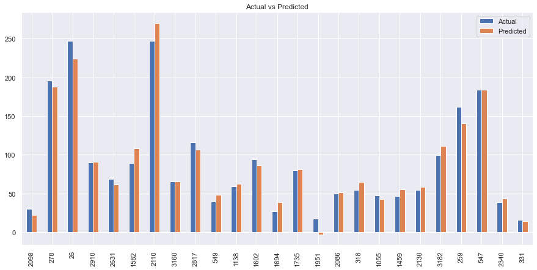

```python
df1 = df_pred_test.sample(25, random_state=1)
df1.plot(kind="bar", figsize=(15, 7), title="Actual vs Predicted")
plt.show()
```

### Model Performance

```python
# checking model performance on train set (seen 70% data)
print("Training Performance\n")
olsmod1_train_perf = model_performance_regression(olsmod1, x_train2, y_train)
olsmod1_train_perf
```

```
Training Performance
```

|  | RMSE | MAE | R-squared | Adj. R-squared | MAPE |
| --- | --- | --- | --- | --- | --- |
| 0 | 14.236 | 10.400 | 0.953 | 0.953 | 18.809 |

```python
# checking model performance on test set (seen 30% data)
print("Test Performance\n")
olsmod1_test_perf = model_performance_regression(olsmod1, x_test2, y_test)
olsmod1_test_perf
```

```
Test Performance
```

|  | RMSE | MAE | R-squared | Adj. R-squared | MAPE |
| --- | --- | --- | --- | --- | --- |
| 0 | 13.851 | 10.155 | 0.957 | 0.956 | 16.290 |

#### Observations:

- - The model is able to explain ~95% of the variation in the data, which is very good.
- - The train and test RMSE and MAE are low and comparable. So, our model is not suffering from overfitting.
- - The MAPE on the test set suggests we can predict within 16% of the used price.
- - Hence, we can conclude the model *olsmod1* is good for prediction as well as inference purposes.

### Model performance between LinearRegression and OLS model

```python
# training performance comparison

models_train_comp_df = pd.concat(
    [linearregression_train_perf.T, olsmod1_train_perf.T], axis=1,
)

models_train_comp_df.columns = [
    "Linear Regression sklearn",
    "Linear Regression statsmodels",
]

print("Training performance comparison:")
models_train_comp_df
```

```
Training performance comparison:
```

|  | Linear Regression sklearn | Linear Regression statsmodels |
| --- | --- | --- |
| RMSE | 14.212 | 14.236 |
| MAE | 10.392 | 10.400 |
| R-squared | 0.954 | 0.953 |
| Adj. R-squared | 0.953 | 0.953 |
| MAPE | 18.733 | 18.809 |

```python
# test performance comparison

models_test_comp_df = pd.concat(
    [linearregression_test_perf.T, olsmod1_test_perf.T], axis=1,
)

models_test_comp_df.columns = [
    "Linear Regression sklearn",
    "Linear Regression statsmodels",
]

print("Test performance comparison:")
models_test_comp_df
```

```
Test performance comparison:
```

|  | Linear Regression sklearn | Linear Regression statsmodels |
| --- | --- | --- |
| RMSE | 13.778 | 13.851 |
| MAE | 10.121 | 10.155 |
| R-squared | 0.957 | 0.957 |
| Adj. R-squared | 0.957 | 0.956 |
| MAPE | 16.259 | 16.290 |

#### Observations:

- We can observe both sklearn LinearRegression and statsmodel OLS gave us pretty much comparable and close results.

### Final Model Summary

```python
olsmodel_final = sm.OLS(y_train, x_train2).fit()
print(olsmodel_final.summary())
```

```
                            OLS Regression Results
==============================================================================
Dep. Variable:             used_price   R-squared:                       0.953
Model:                            OLS   Adj. R-squared:                  0.953
Method:                 Least Squares   F-statistic:                     6360.
Date:                Fri, 20 Aug 2021   Prob (F-statistic):               0.00
Time:                        12:16:25   Log-Likelihood:                -10183.
No. Observations:                2499   AIC:                         2.038e+04
Df Residuals:                    2490   BIC:                         2.044e+04
Df Model:                           8
Covariance Type:            nonrobust
====================================================================================
                       coef    std err          t      P>|t|      [0.025      0.975]
------------------------------------------------------------------------------------
const               63.0940      1.397     45.154      0.000      60.354      65.834
main_camera_mp      -0.2056      0.083     -2.480      0.013      -0.368      -0.043
selfie_camera_mp     0.7288      0.089      8.177      0.000       0.554       0.904
int_memory           0.0855      0.010      8.519      0.000       0.066       0.105
days_used           -0.0851      0.001    -57.937      0.000      -0.088      -0.082
new_price            0.3874      0.003    138.027      0.000       0.382       0.393
os_Others           -5.4782      1.273     -4.302      0.000      -7.975      -2.981
os_iOS               6.7202      2.450      2.743      0.006       1.917      11.524
4g_yes              -3.1396      0.804     -3.906      0.000      -4.716      -1.563
==============================================================================
Omnibus:                      289.728   Durbin-Watson:                   1.968
Prob(Omnibus):                  0.000   Jarque-Bera (JB):              647.566
Skew:                           0.693   Prob(JB):                    2.41e-141
Kurtosis:                       5.073   Cond. No.                     6.43e+03
==============================================================================

Notes:
[1] Standard Errors assume that the covariance matrix of the errors is correctly specified.
[2] The condition number is large, 6.43e+03. This might indicate that there are
strong multicollinearity or other numerical problems.
```

#### Observations:

- Model is able to explain ~95% of the variance
- None of the features used in final model are having p-value over .05

## Actionable Insights and Recommendations

**Insights**

1. Android phones with close to ~91% are predominant in used phone market.
2. Used phones having 4g features are popular in market
3. 5g phones are yet to hit used phone market, as it is newer technology.
4. Samsung is the market leader in used phone market, Huawei and LG are the next two brands which are popular
5. Budget phones (average new prices < 200 euros) are most sold phones in used market, LG is the most popular brand in this category.
6. Huawei and Samsung are market leaders in bigger screen phones.
7. Infinix is the lowest performing brand in used phone market.
8. On average Oneplus phones have higher ram.
9. Xiaomi offers best selfie cameras in budget phones.
10. Phone's cameras main and selfie, internal memory, how many days the phone have been used, what was the new price of the phone are some of the most important factor which drives the price of used phones

**Recommendations**

1. Inventory of different Android phones, specifically with some must have brands such as Samsung, Huawei, LG, Xiaomi should be ensured.
2. Budget phones should be targeted for volume selling.
3. Targeted marketing for multimedia use should be done with Huawei, Samsung phones.
4. Targeted marketing for gaming use should be done with OnePlus phones.
5. Targeted marketing for great selfie phones in budget should be done with Xiaomi phones.
6. 5g Phones are yet to hit market in full fledge as it's a new technology, Tapping into this market likely to increase sales and revenue.
7. ML solutions should be leveraged to generate the pricing for their used phone inventories.